# STAT 184 Final Project: Matt Bubb and Jacob Adams

## Research idea: Expondential Growth and the Novel Coronavirus

#### Our final project is based around the concept of exponential growth when applied to the Novel Coronavirus (COVID-19). Although our main idea is not surrounded by a question, we have explored many sub-questions related to the topic in which we can draw trivial commonalities between the Coronavirus and exponential growth. Our research topics are listed below in our figure listings.

Figure 1: Can we safely conclude that the cases worldwide are indeed spreading exponentially?  
Figure 2: This is an add on to Figure 2 to help the user visualize Figure 1 better.  
Figure 3: How does the total deaths from COVID-19 relate to the number of new deaths each day?  
Figure 4: Since we are intersted in exponential growth, what is the average number of days it takes for the total number of COVID-19 cases to double in the world?  
Figure 5: Which countries have the highest death rate per 100 people; are these numbers growing exponentially?  
Figure 6: This is an addition to Figure 5, as we added another parameter to the problem.  
Figure 7: Has the number of tests grown exponentially with the number of confirmed cases?  
Figure 8: Tests per confirmed cases.  
Figure 9: Taking look at the exponential growth in the U.S over the past month.

```r
rm(list = ls())

library(DataComputing)
library(lubridate)
library(dplyr)
data1 <- read.csv("owid-covid-data.csv")
data2 <- read.csv("full_data.csv")
```

# Data Inspection

## First Dataset

###### Data URL: https://ourworldindata.org/coronavirus-source-data

```r
head(data2)
```

|  | date | location | new_cases | new_deaths | total_cases | total_deaths |
| --- | --- | --- | --- | --- | --- | --- |
| 1 | 2019-12-31 | Afghanistan | 0 | 0 | 0 | 0 |
| 2 | 2020-01-01 | Afghanistan | 0 | 0 | 0 | 0 |
| 3 | 2020-01-02 | Afghanistan | 0 | 0 | 0 | 0 |
| 4 | 2020-01-03 | Afghanistan | 0 | 0 | 0 | 0 |
| 5 | 2020-01-04 | Afghanistan | 0 | 0 | 0 | 0 |
| 6 | 2020-01-05 | Afghanistan | 0 | 0 | 0 | 0 |

## Second Dataset

###### Data URL: https://ourworldindata.org/coronavirus#licence

```r
head(data1)
```

|  | iso_code | location | date | total_cases | new_cases | total_deaths | new_deaths | total_cases_per_million | new_cases_per_million | total_deaths_per_million | new_deaths_per_million | total_tests | new_tests | total_tests_per_thousand | new_tests_per_thousand | tests_units |
| --- | --- | --- | --- | --- | --- | --- | --- | --- | --- | --- | --- | --- | --- | --- | --- | --- |
| 1 | ABW | Aruba | 2020-03-13 | 2 | 2 | 0 | 0 | 18.733 | 18.733 | 0 | 0 | NA | NA | NA | NA |  |
| 2 | ABW | Aruba | 2020-03-20 | 4 | 2 | 0 | 0 | 37.465 | 18.733 | 0 | 0 | NA | NA | NA | NA |  |
| 3 | ABW | Aruba | 2020-03-24 | 12 | 8 | 0 | 0 | 112.395 | 74.930 | 0 | 0 | NA | NA | NA | NA |  |
| 4 | ABW | Aruba | 2020-03-25 | 17 | 5 | 0 | 0 | 159.227 | 46.831 | 0 | 0 | NA | NA | NA | NA |  |
| 5 | ABW | Aruba | 2020-03-26 | 19 | 2 | 0 | 0 | 177.959 | 18.733 | 0 | 0 | NA | NA | NA | NA |  |
| 6 | ABW | Aruba | 2020-03-27 | 28 | 9 | 0 | 0 | 262.256 | 84.296 | 0 | 0 | NA | NA | NA | NA |  |

# Data Wrangling

## First data set -> used mostly for cases and deaths

```r
casesDf <-
data2 %>%
group_by(date) %>%
summarise(newCases = sum(new_cases),totalDeaths = sum(total_deaths) ,newDeaths = sum(new_deaths), totalCases = sum(total_cases)) %>%
arrange(desc(date))

casesDf$date = as.character.Date(levels(casesDf$date))[casesDf$date]

graph <-
casesDf%>%
mutate(daysSinceDecember312019 = as.numeric(floor((difftime(casesDf$date, min(casesDf$date))/86400 )) ))
```

## Second data set -> used for testing and cases

```r
data1[is.na(data1)] <- 0

testDf <-
  data1 %>%
  group_by(date) %>%
  summarise(totalCases = sum(total_cases), newCases = sum(new_cases),totalDeaths = sum(total_deaths), totalTests = sum(total_tests), newTests = sum(new_tests) )

testDf$date = as.character.Date(levels(testDf$date))[testDf$date]

graph2 <-
  testDf%>%
  mutate(daysSinceDecember312019 = as.numeric(floor((difftime(testDf$date, min(testDf$date))/86400 )) ))
```

## Figure #1

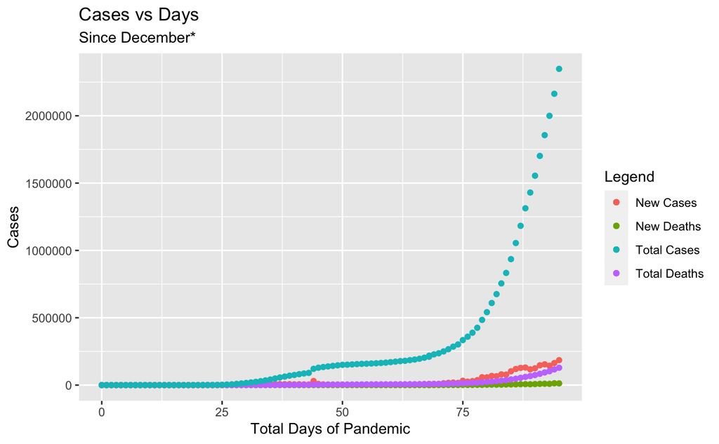

```r
ggplot(data = graph, aes(daysSinceDecember312019)) +
  geom_point(aes(y = newCases, color = "New Cases")) +
  geom_point(aes(y = newDeaths, color = "New Deaths")) +
  geom_point(aes(y = totalDeaths, color = "Total Deaths")) +
  geom_point(aes(y = totalCases, color = "Total Cases")) +
  ggtitle("Cases vs Days", subtitle = "Since December*") +
  xlab("Total Days of Pandemic") + ylab("Cases") + labs(color = "Legend" )
```

This is a very nice overlay of new cases, new deaths, total cases, and total deaths. This also really shows the dramatic explosion of total cases towards the end of the graph which in turn, lessens the visual importance of the other three categories. Because of this, we made a second graph below of the same variables with the removal of total cases to show how the other three variables have transformed through time.

## Figure #2

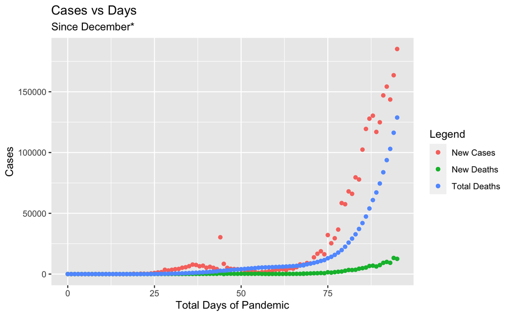

```r
ggplot(data = graph, aes(daysSinceDecember312019)) +
  geom_point(aes(y = newCases, color = "New Cases")) +
  geom_point(aes(y = newDeaths, color = "New Deaths")) +
  geom_point(aes(y = totalDeaths, color = "Total Deaths")) +
  ggtitle("Cases vs Days", subtitle = "Since December*") +
  xlab("Total Days of Pandemic") + ylab("Cases") + labs(color = "Legend" )
```

## Figure #3

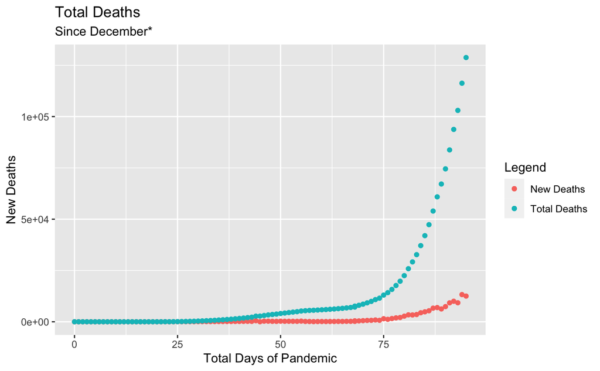

```r
ggplot(data = graph, aes(daysSinceDecember312019))  +
  geom_point(aes(y = newDeaths, color = "New Deaths")) +
  geom_point(aes(y = totalDeaths, color = "Total Deaths")) +
  ggtitle("Total Deaths", subtitle = "Since December*") +
  xlab("Total Days of Pandemic") + ylab("New Deaths") + labs(color = "Legend" )
```

We can see here that the number of total deaths is, unfortunately, exponential. The number of new deaths also looks to be taking off in an exponential fashion.

## Figure #4

Up next, we are interested to see how often the total number of cases around the world doubles. As the most common form of exponential growth $f(x) = 2^x$, grows at an incredible rate and in the case of the Coronavirus, the number of cases could grow incredibly fast. Below, we have written a user defined function to calculate on average, the number of days it takes for the total amount of cases to double.

```r
totalCasesColumn <- rev(casesDf$totalCases)
total = 1
countDays = 0
doubleList = 0
n = 0
for (i in seq_along(totalCasesColumn)){
  countDays = countDays + 1
  checkForDouble = totalCasesColumn[i]
  if(checkForDouble > total * 2  ){
    total = checkForDouble
    doubleList = doubleList + countDays
    n = n + 1
    countDays = 0
  }
}

print(paste("On average the amount of days for COVID-19 cases to double is:", floor(doubleList / n)))
```

```
[1] "On average the amount of days for COVID-19 cases to double is: 6"
```

Since we have seen that these are exponential growths, we wanted to find the countries that are, unfortunatley, expierences the highest death rates from the Coronavirus. This data can be very useful in order to find which countries need the most help and start to analyze what they might they might be doing to have this death rate so high. Here, we calculated the highest death rate around the world

## Figure #5

```r
data2test <-
  data2 %>%
  group_by(location)

data2test$date = as.character.Date(levels(data2test$date))[data2test$date]

deathRate <-
  data2test %>%
  filter(date == "2020-04-05" ) %>%
  mutate(death_rate = (total_deaths/total_cases)*100)%>%
  arrange(desc(death_rate))

finalDeathRate <-
  subset(deathRate, select = c(location, death_rate))
finalDeathRate
```

| location | death_rate |
| --- | --- |
| Botswana | 25.0000000 |
| Gambia | 25.0000000 |
| Angola | 20.0000000 |
| Nicaragua | 20.0000000 |
| Sudan | 20.0000000 |
| Guyana | 16.6666667 |
| Mauritania | 16.6666667 |
| Bahamas | 14.2857143 |
| Cape Verde | 14.2857143 |
| Northern Mariana Islands | 12.5000000 |

[output cut: 192 more lines]

## Figure #6

```r
data2test <-
  data2 %>%
  group_by(location)
data2test$date = as.character.Date(levels(data2test$date))[data2test$date]

deathRate <-
  data2test %>%
  filter(date == "2020-04-05" & total_cases > 10000 ) %>%
  mutate(death_rate = (total_deaths/total_cases)*100)%>%
  arrange(desc(death_rate))

finalDeathRate <-
  subset(deathRate, select = c(location, death_rate))
finalDeathRate
```

| location | death_rate |
| --- | --- |
| Italy | 12.325887 |
| France | 11.019605 |
| United Kingdom | 10.292819 |
| Netherlands | 9.929633 |
| Spain | 9.415085 |
| Belgium | 6.961098 |
| Iran | 6.192706 |
| World | 5.482475 |
| Brazil | 4.203152 |
| China | 4.036331 |

[output cut: 8 more lines]

This is a lot more accuracte to today’s numbers (Again note that this data accounts for cases only up until April 5th, 2020. )

Finally, below, we wanted to explore the growth rates while comparing the COVID-19 tests and the number of cases. First, we have a graph showing the exponetial explosion of total tests and total cases during the pandemic.

## Figure #7

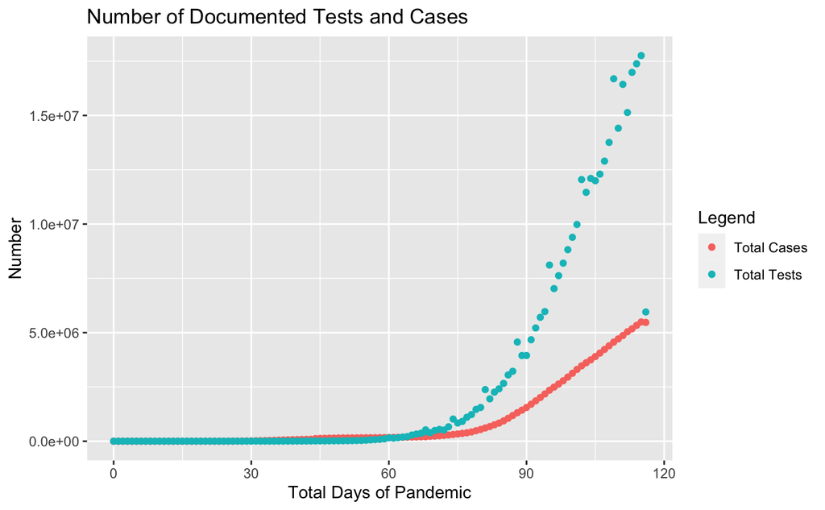

```r
#tests vs cases

ggplot(data = graph2, aes(x = daysSinceDecember312019))  +
  geom_point(aes(y = as.integer(totalCases), color = "Total Cases"))  +
  geom_point(aes(y = as.integer(totalTests), color = "Total Tests")) +
  ggtitle("Number of Documented Tests and Cases ") +
  xlab("Total Days of Pandemic") + ylab("Number") + labs(color = "Legend" )
```

This goes to show just how much testing has been done so far. Although these are failry large numbers, testing still needs to dramatically increase.

## Figure #8

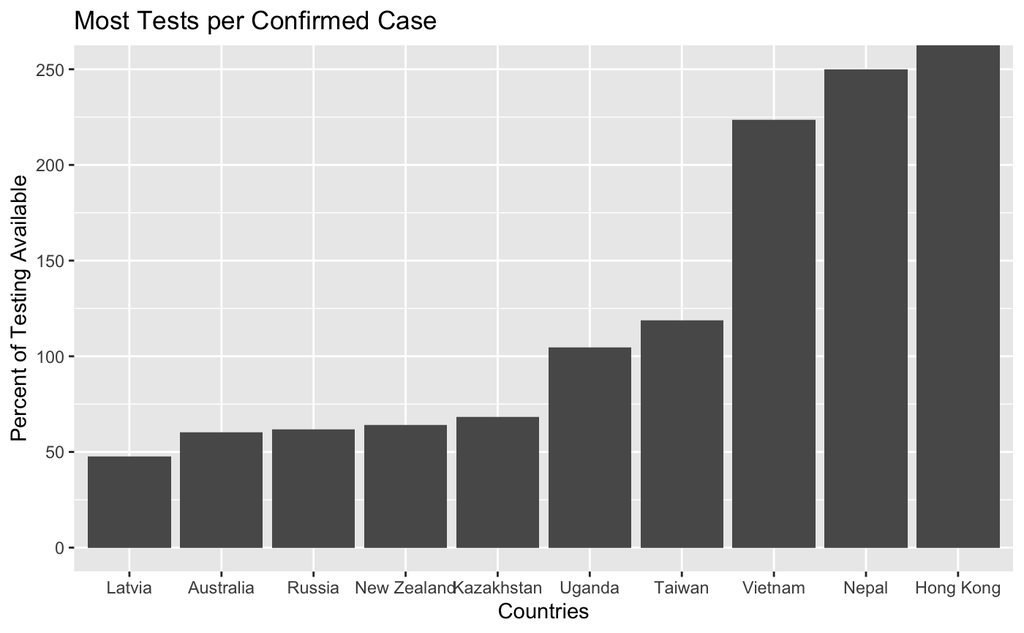

```r
#Most Tests per confirmed case
country <- data1 %>%
  group_by(location) %>%
  summarise(totalCases = sum(total_cases), newCases = sum(new_cases),totalDeaths = sum(total_deaths), totalTests = sum(total_tests) ) %>%
  mutate(ratio = (as.integer(totalTests)/totalCases)) %>%
  arrange(desc(ratio))

ggplot(data = head(country, n = 10 ), aes(x = reorder(location, (as.integer(totalTests)/totalCases)), y = (as.integer(totalTests)/totalCases))) +
  geom_bar(stat = "identity") +
  ggtitle("Most Tests per Confirmed Case") +
  xlab("Countries") + ylab("Percent of Testing Available") + labs(color = "Legend" )
```

Here, we have another graph, this time a bar chart, showing the number of tests per confirmed cases worldwide. For simplicity we are showing the top ten countries. This is an interesting graphic as it shows that these countries have the fewest number of cases per test.

## Figure #9

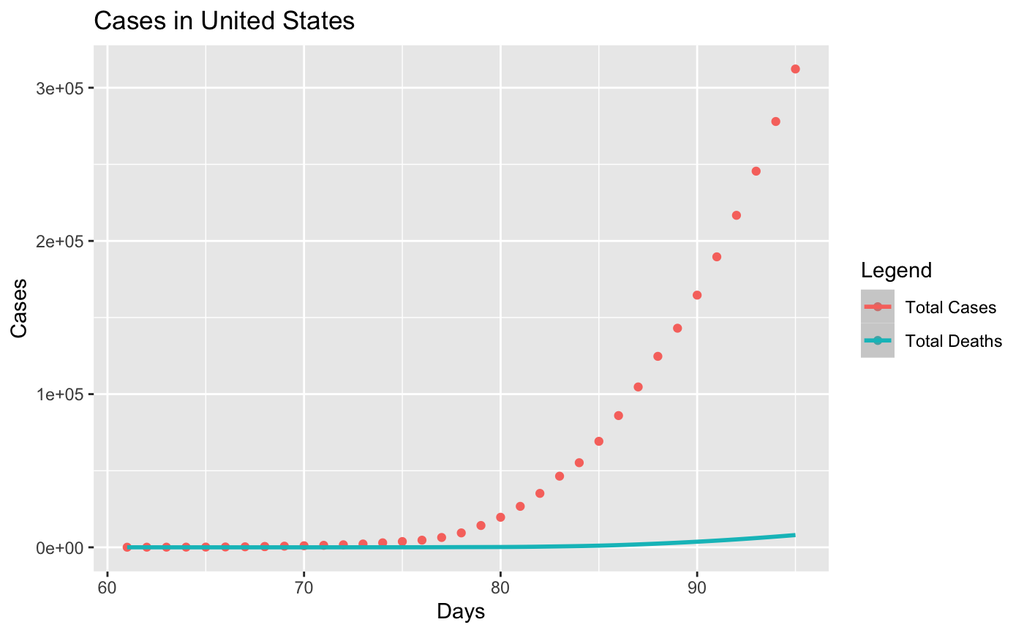

```r
casesUS <-
data2 %>%
  filter(location == "United States") %>%
  group_by(date) %>%
  summarise(newCases = sum(new_cases),totalDeaths = sum(total_deaths) ,newDeaths = sum(new_deaths), totalCases = sum(total_cases)) %>%
  arrange(desc(date))

casesUS$date = as.character.Date(levels(casesUS$date))[casesUS$date]

graphUS <-
  casesUS%>%
  mutate(daysSinceDecember312019 = as.numeric(floor((difftime(casesDf$date, min(casesDf$date))/86400 )) )) %>%
  filter(daysSinceDecember312019 > 60)

ggplot(data = graphUS, aes(daysSinceDecember312019)) +
  geom_point(aes(y = totalCases, color = "Total Cases")) +
  geom_smooth(aes(y = totalDeaths, color = "Total Deaths")) +
  ggtitle("Cases in United States") +

  xlab("Days") + ylab("Cases") + labs(color = "Legend" )
```

This graph demonstrates the exponention growth in the United States within the last 30 + days. We can safe conclude that spread is exponential in the U.S as well.